# NLP

STOR 390

# Corpus

- Corpus = collection of documents
  - 7 Harry Potter books
  - 20,000 NYT articles

# TidyText: book-word rows

- each row is one word from one book

# Harrpy Potter

```r
books
```

```
## # A tibble: 38,954 × 4
##                                                            text linenumber
## *                                                         <chr>      <int>
## 1                       Harry Potter and the Chamber of Secrets          1
## 2                                                            by          2
## 3                                                 J. K. Rowling          3
## 4                                Illustrations By Mary Grandpré          4
## 5                                        Arthur A. Levine Books          5
## 6                               An Imprint Of Scholastic Press.          6
## 7                                        For Seán P. F. Harris.          7
## 8                        Getaway driver and foul-weather friend          8
## 9                       Text copyright © 1999 by J. K. Rowling.          9
## 10 Illustrations by Mary GrandPré copyright © 1999 Warner Bros.         10
## # ... with 38,944 more rows, and 2 more variables: author <chr>,
## #   book <chr>
```

# Book-word rows

```r
#make rows book-word pairs
book_words <- books %>%
    unnest_tokens(word, text)
book_words
```

```
## # A tibble: 1,092,986 × 4
##    linenumber  author            book    word
##         <int>   <chr>           <chr>   <chr>
## 1           1 rowling chamber_secrets   harry
## 2           1 rowling chamber_secrets  potter
## 3           1 rowling chamber_secrets     and
## 4           1 rowling chamber_secrets     the
## 5           1 rowling chamber_secrets chamber
## 6           1 rowling chamber_secrets      of
## 7           1 rowling chamber_secrets secrets
## 8           2 rowling chamber_secrets      by
## 9           3 rowling chamber_secrets       j
## 10          3 rowling chamber_secrets       k
## # ... with 1,092,976 more rows
```

# Term-frequency

```r
# count number of times each word appears in each book
book_words <- book_words %>%
    count(book, word, sort = TRUE) %>%
    ungroup()

book_words
```

```
## # A tibble: 70,486 × 3
##                 book  word     n
##                <chr> <chr> <int>
## 1      order_phoenix   the 11744
## 2    deathly_hallows   the 10485
## 3        goblet_fire   the  9340
## 4  half_blood_prince   the  7527
## 5      order_phoenix    to  6346
## 6      order_phoenix   and  6280
## 7    deathly_hallows   and  5563
## 8      order_phoenix    of  5368
## 9   prisoner_azkaban   the  5126
## 10       goblet_fire   and  4973
## # ... with 70,476 more rows
```

# Most common words in each book

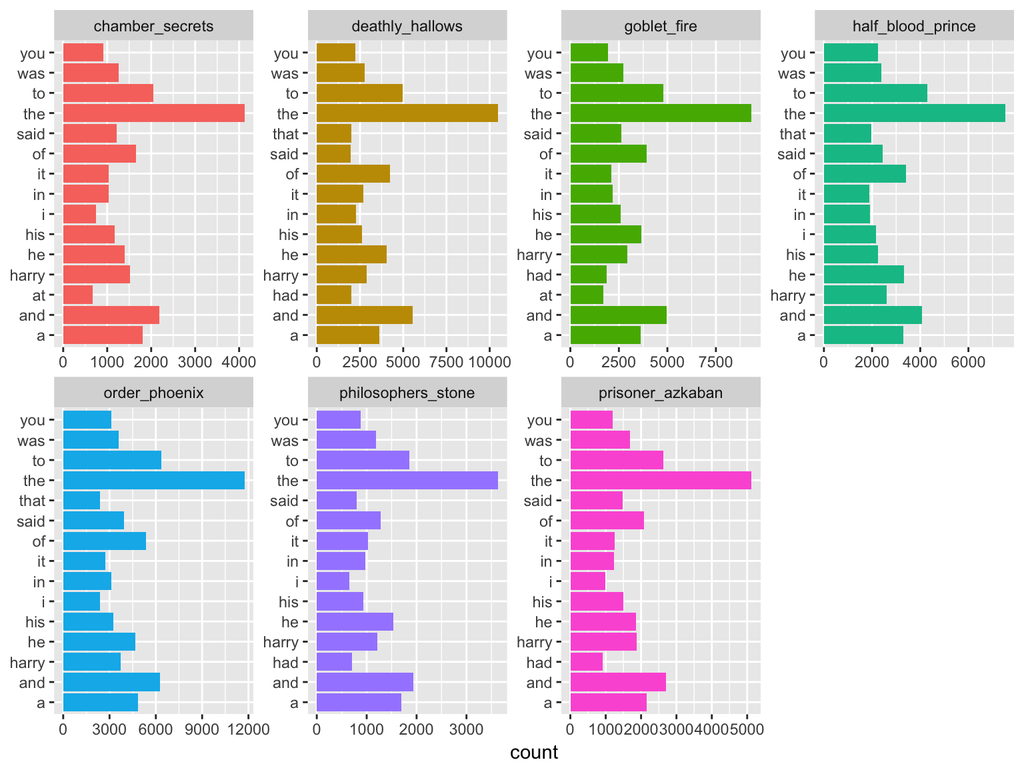

# Term frequency distribution

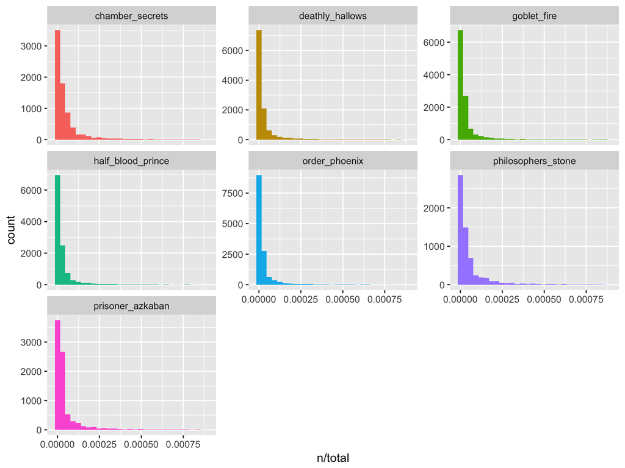

# Heavy tail

- A few words appear a lot!

# Zipf’s law

The frequency that a word appears is inversely proportional to its rank.

# Zipf’s law

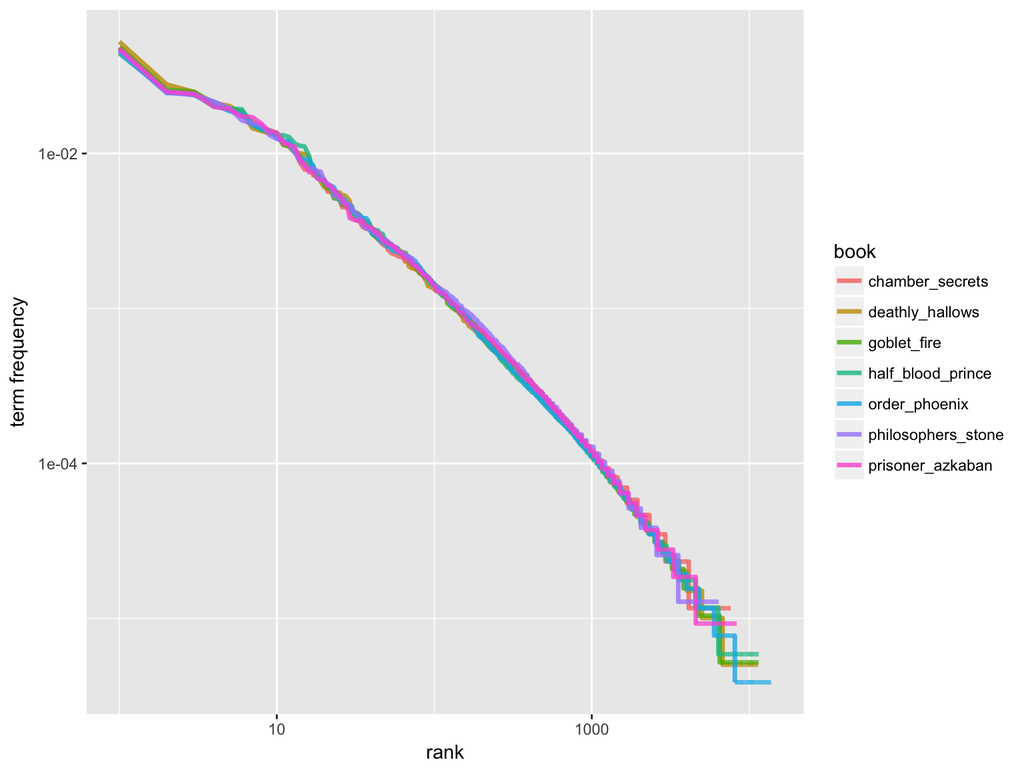

# Term frequency is driven by commonly occuring wrods

- “the” appears many times
- common words may not be interesting
- somehow downweight commonly occuring words

# Inverse document frequency

$$\text{idf}(\textbf{word}) = \ln \left( \frac{\text{total number of documents}}{\text{number of documents containing } \textbf{word}} \right)$$

# Term frequency, inverse document frequency

idf downweights the term frequency
$$\text{tf-idf}(w) = \text{tf}(w) \cdot \text{idf}(w)$$

# compute tf-idf scores

```r
book_words <- book_words %>%
    bind_tf_idf(word, book, n)
```

```
## # A tibble: 70,486 × 6
##                 book        word     n           tf       idf       tf_idf
##                <chr>       <chr> <int>        <dbl>     <dbl>        <dbl>
## 1  half_blood_prince    slughorn   335 0.0019664356 1.2527630 0.0024634777
## 2      order_phoenix    umbridge   473 0.0018285211 0.8472979 0.0015493020
## 3        goblet_fire      bagman   203 0.0010555270 1.2527630 0.0013223251
## 4    chamber_secrets    lockhart   193 0.0022438208 0.5596158 0.0012556775
## 5   prisoner_azkaban       lupin   372 0.0034408761 0.3364722 0.0011577593
## 6        goblet_fire       winky   145 0.0007539478 1.2527630 0.0009445179
## 7        goblet_fire   champions    83 0.0004315701 1.9459101 0.0008397967
## 8    deathly_hallows xenophilius    85 0.0004263815 1.9459101 0.0008297000
## 9    deathly_hallows    griphook   120 0.0006019503 1.2527630 0.0007541011
## 10 half_blood_prince    mclaggen    65 0.0003815472 1.9459101 0.0007424566
## # ... with 70,476 more rows
```

# words with highest tf-idf scores

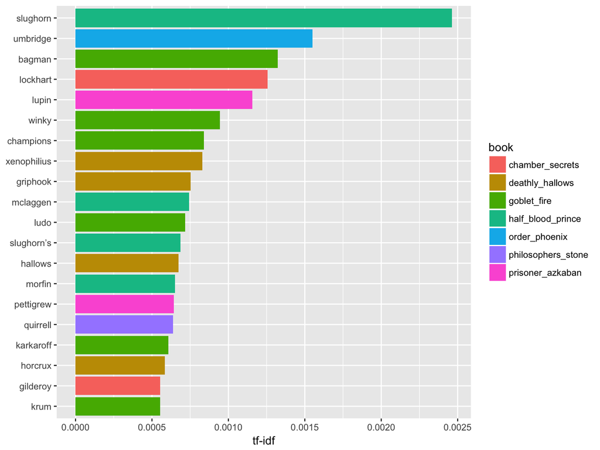

# TF-IDF by book

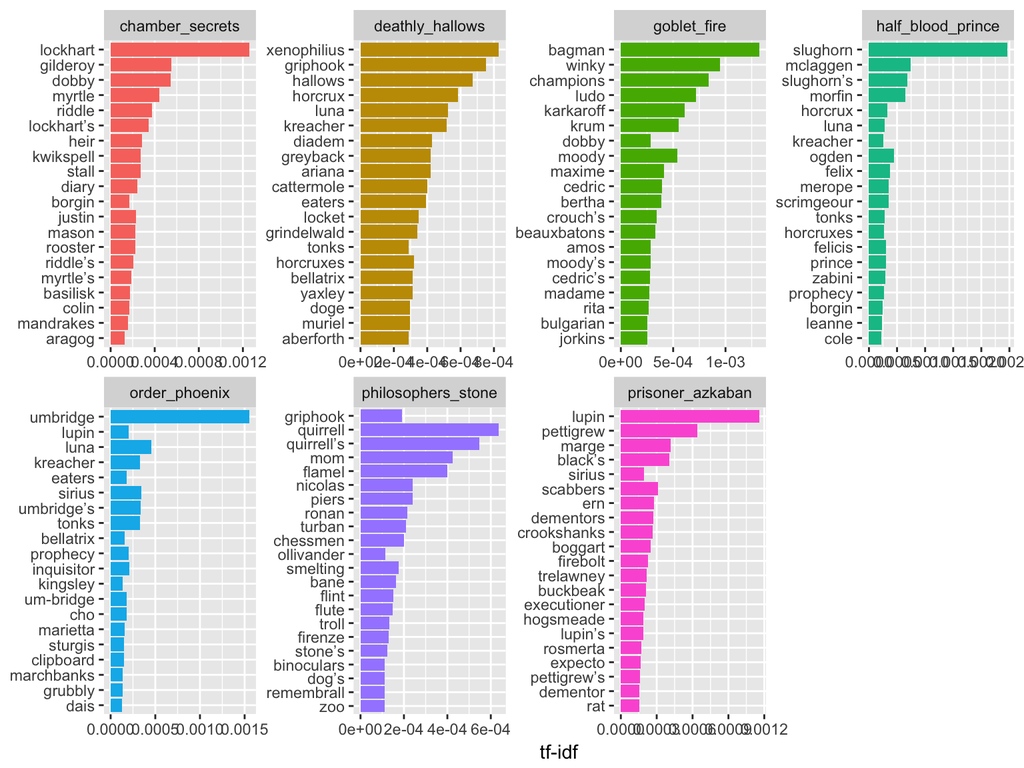

# Text normalization

- pick a cannonical representation of a word
  - Dog, dog, dogs
- lower case
- stemming/lemmatization

# All words

```
##  [1] "Harry"      "Potter"     "and"        "the"        "Sorcerer’s"
##  [6] "Stone"      "by"         "J"          "K"          "Rowling"
```

# Unique words

```r
all_words %>% unique %>% length
```

```
## [1] 7268
```

# Unique words after lower casing

```r
all_words %>% unique %>% length
```

```
## [1] 7268
```

```r
all_words %>%  str_to_lower %>% unique %>% length
```

```
## [1] 6390
```

# Stemming

- Goal: reduce word to base form
  - am, are, is $\Rightarrow$ be
  - car, cars, car’s, cars’ $\Rightarrow$ car

# Porter stemmer

```r
library(SnowballC)

wordStem(c("argue", "argued", "argues", "arguing", "argus", "argument", "arguments"))
```

```
## [1] "argu"     "argu"     "argu"     "argu"     "argu"     "argument"
## [7] "argument"
```

```r
wordStem(c("dog", "dogs"))
```

```
## [1] "dog" "dog"
```

```r
wordStem(c("crying", "cried", "cries"))
```

```
## [1] "cry" "cri" "cri"
```

```r
wordStem(c('am', 'are', 'is'))
```

```
## [1] "am" "ar" "i"
```

# Unique words after lower casing and stemming

```r
all_words %>% unique %>% length
```

```
## [1] 7268
```

```r
all_words %>%  str_to_lower %>% unique %>% length
```

```
## [1] 6390
```

```r
all_words %>%  wordStem %>% str_to_lower %>% unique %>% length
```

```
## [1] 4839
```

# top tf-idf before stemming

```r
# which tf-idf ranks to show
word_range <- 30:45
```

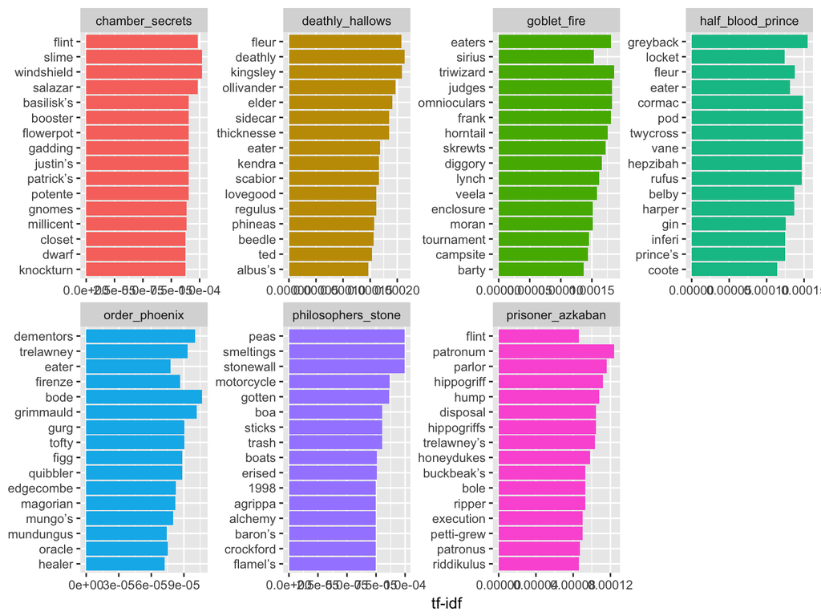

# top tf-idf after stemming

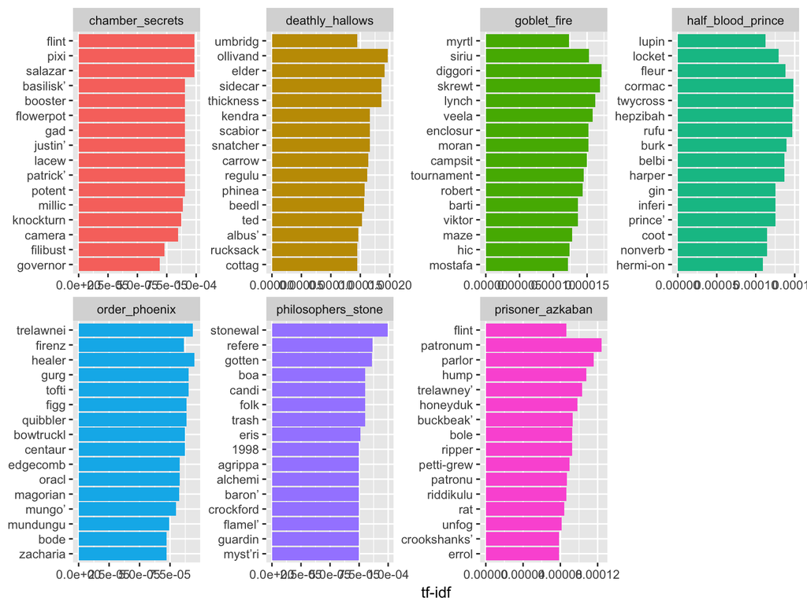

# Document-term matrix (bag of words)

- rows = documents
- columns = words
- values = count

# Document-term matrix (bag of words)

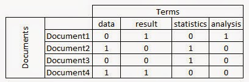

# tf-idf matrix

- values = tf-idf scores
- rescale columns of bag of words matrix

# George Orwell texts

- 40 essays by George Orwell
- 12177 unique words
- break essays into chucks (6144 chuncks)

# Clasificaiton task

- X = document term matrix (6144 x 12177 matrix)
  - raw counts or tf-idf scores
- Y = book titles (40 classes)

# Sparse matrices

- document term matrices are (usually sparse)
- faster
- less memory

# Mean difference classifier

- Two different data object representations
  - bag of words matrix
  - tf-idf matrix

# Training error comparision

- bag of words: 19% error rate
- tf-idf: 5% error rate